# Extraction elevation values from DEM

[figure not shown]

# Introduction

In this 21st Century, depending on the accuracy, level of urgency, or measure of your integrity, there are two ways of collecting elevation values from any point on the Earth's surface. One is to go the field, and like a true surveyor, collect the GPS points with a GPS handheld device or a smartphone. Most GPS handlheld devices and GPS apps collect both Lon-Lat coordinates with their corresponding altitudes. If you are the lazy type, are allergic to fieldwork or are severely limited in time and money, looking for a DEM dataset online is very much welcome. For today, we shall concentrate on extracting elevation values at specific GPS coordinates all in python. Well, almost.

## Load the DEM

First things first. We will have to load the Digital Elevation Model (DEM). DEMs come in various formats. In our very few years on this planet we have mostly come across `.tif`, `.hdr` and `.adf` formats. Howver, `.tif` formats are the most common and easiest to work with. You'd probably need to re-consider your GIS and Remote Sensing experience if you are yet to come across `.tif` somewhere. Anyway, we were talking about accessing the DEM. They also vary in terms of resolution. A DEM of 20m resolution is more accurate than that of 100m resolution. In our case, the DEM that beats many in their game is the [ALOS PALSAR DEM](https://asf.alaska.edu/data-sets/sar-data-sets/alos-palsar/alos-palsar-about/) that has a spatial resolution of 12.5m. We know there are other DEMs sharper than this, but they don't come cheap. For hitchhikers like us, the ALOS PALSAR datasets available from [ASF Alaska website](https://asf.alaska.edu/data-sets/sar-data-sets/alos-palsar/alos-palsar-about/) are our best deal so far. This article will not go into the details of accessing them, but this [You Tube video](https://www.youtube.com/watch?v=tvThwNYI-uw&t=221s) saves us a lot of words .

We have also provided the shapefile we used as the Area of Interest (AOI) boundary, it is [here](https://www.dropbox.com/scl/fo/3f6f739651zybmrxho68s/h?dl=0&rlkey=vcaxax7ayj93guwd9vr42osmo).

After downloading the DEM, we will clip it to our AOI. In case you are lost in the data ocean of the ASF Alaska website, we have gone the extra mile of [downloading the DEM](https://www.dropbox.com/s/wko1l6higq5bpyf/AP_09915_FBS_F7150_RT1.dem.tif?dl=0) for you. Uncle Sam (the writer, not USA) cares after all. For the tough ones who don't mind getting lost in the data ocean of the Alaska AFS website, look for the file name `AP_09915_FBS_F7150_RT1` from the list of image tiles.

We had also mentioned clipping in addition to acquiring the DEM. As often mentioned, in remote sensing as well as in programming it is better to work with bits rather than the entire bite. Working with the focus area saves time, prevents confusion and is friendly to your finite computer resources. But we are jumping ahead of the gun. Let's first open the zip folder of our DEM.

```python
# Package used in the exercise
from zipfile import ZipFile
import os
import fiona
import rasterio
import rasterio.mask
import matplotlib.pyplot as plt
import geopandas as gpd
import pandas as pd
import fiona
import cartopy.crs as ccrs
import xarray
import rioxarray
```

Here's the path to our DEM zip file.

```python
# Path to the DEM
path = "E:/documents/gis800_articles/jupyter/terrain_dem"
```

Now let's use the `ZipFile` package to extract our DEM zip contents.

```python
# Now use the zipfile tool to extract DEM
with ZipFile(os.path.join(path, "AP_09915_FBS_F7150_RT1.zip"), 'r') as zObject:
             zObject.extractall(os.path.join(path, 'alos_dem'))
```

Now note somewhere the full path to your DEM file. It's never a pain to double check the results of your code.

```python
# Already extracted
# Full path to DEM is
dem_path = os.path.join(path, 'alos_dem', 'AP_09915_FBS_F7150_RT1', 'AP_09915_FBS_F7150_RT1.dem.tif')
print(dem_path)
```

```
E:/documents/gis800_articles/jupyter/terrain_dem\alos_dem\AP_09915_FBS_F7150_RT1\AP_09915_FBS_F7150_RT1.dem.tif
```

## Clip the DEM

Now is the time to clip our DEM. We will first load in the necessary packages for dealing with geospatial data. We have hashed the package names because in programming, it is good practice to call all your necessary packages at the top, rather than within the file. That is one mark of a polished programmer. But just for today we break the rules for your sake. Tomorrow we shall have the 'professional' coat back on.

```python
## The DEM is too huge.
## Needs to be clipped.
# import fiona
# import rasterio
# import rasterio.mask
```

Just as we cannot surgically operate on ourselves, so DEM files cannot clip themselves. We will use the same shapefile that you used to search for the DEM in the ASF Alaska website for clipping. Let's call it from our directory. We hope you have downloaded it too.

```python
# Shapefile for clipping
shapefile_path = os.path.join(path, 'bounding.shp')
```

If you have worked in Qgis before, you know clipping a DEM is darn straightforward. But in Python, it's a long and scary process. We also confess we stood on the shoulders of giants to do it ourselves. We used this methodology from [Stack Overflow](https://stackoverflow.com/questions/69938501/clipping-raster-through-a-shapefile-using-python?utm_source=pocket_reader).

The stack responses were a lifesave but Let's get on with it.

First open and extract the geometry of the shapefile.

```python
with fiona.open(shapefile_path, "r") as shapefile:  # Open the shapefile from the path given
    shapes = [feature["geometry"] for feature in shapefile]  # a list comprehension for loop that means for every feature in the shapefile (if
    # composed of many features) extract the geometry
```

Now let's open the raster DEM, and clip it to our shapefile bounds using the `rasterio.mask` function.

```python
with rasterio.open(dem_path) as elev_dem:   # Open the raster

    out_image, out_transform = rasterio.mask.mask(elev_dem, shapes, crop=True)  # Mask out the raster
    out_meta = elev_dem.meta       # Assign the metadata of the clipped raster to the variable 'out_meta'
```

## Update the metadata of the clipped DEM

After clipping, of course the metadata will not remain the same. It too must reflect the changes.

```python
# Update metadata
out_meta.update({"driver": "GTiff",
                 "height": out_image.shape[1], # Assign the height values of the clipped image to metadata using the shape method??
                 "width": out_image.shape[2],  # Assign the width values of the clipped image to metadata using the shape method??
                 "transform": out_transform})
```

Apart from saving the metadata, it's also worthwile to have a copy of our clipped DEM. The following code will save it to our specified directory.

```python
# Save raster image to directory
with rasterio.open(os.path.join(path, 'dem_files', 'clipped_dem.tif'), "w", **out_meta) as dest:
    dest.write(out_image)
```

Remember the `.shape` methods we used when assigning new bounds to our clipped DEM's metadata? We are curious to not only know what they do, but what values they assigned to images' bounds --the height and width values. Are you too? Let's find out anyway.

```python
# Confirm your clipped images metadata
print(out_image.shape[0])
print(out_image.shape[1])
print(out_image.shape[2])
```

```
1
426
867
```

Alright.

## Display the clipped DEM

Let's view our clipped DEM. We will use `rasterio`'s open function to load the DEM into our environment.

```python
# View the shapefile
# First get the path to the clipped DEM
clipped_dem = rasterio.open(os.path.join(path, 'dem_files', 'clipped_dem.tif'))
```

Now let's view the DEM using `rasterio.plot()`. In case your undestanding has been drifting ever since `rasterio` came into the picture, just know `rasterio` is the package names while anything after the dot (`.`) is a method within that package.

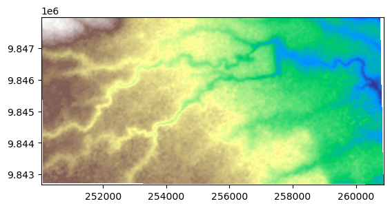

```python
from rasterio.plot import show
show(clipped_dem, cmap='terrain')
```

Are you growing impatient now? Have you been following along? We sure hope! We are just about to enter into the phase of extracting our elevation values. But first, we have to call into python the file containing our [GPS points](https://www.dropbox.com/s/vp17i2g3c6nmd97/gps_readings.csv?dl=0).

```python
# Read your gps points file
# They do not have elevation values
gps_only = pd.read_csv(os.path.join(path, 'gps_files', 'gps_readings.csv'))
gps_only.head()
```

|  | Point | Latitude | Longitude | Accuracy(m) | Description |
| --- | --- | --- | --- | --- | --- |
| 0 | 1 | -1.390684 | 36.769671 | 4 | Junction at Magadi road |
| 1 | 2 | -1.398675 | 36.790664 | 9 | Start of murram road |
| 2 | 3 | -1.397448 | 36.798129 | 3 | Bend before reaching the bridge crossing river... |
| 3 | 4 | -1.397348 | 36.798175 | 5 | a few metres to the bridge |
| 4 | 5 | -1.399695 | 36.799621 | 3 | A group of zebras were sighted grazing in an o... |

Alright. Before we extract the elevation values, we want to view if our GPS points above overlie the DEM. They could as well be completely off course for any particular reason if we don't check! One can't plot a pandas dataframe, much less a CSV file on top of a raster. We have to first convert it to a geodataframe. That's easy enough. Now we come to plotting. Obviously there must be a way to plot both a raster and a geodataframe together in matplotlib. However, we found using matplotlib too challenging and prone to countless errors. Since we did the hardwork for you, you won't undergo the same wild goose chase. We came across a better tool built specifically for spatial graphics. Drum rolls, please... all hail to the `cartopy` package.

There is a caveat, though, in using cartopy to display, as per an [example we followed here](https://geophysics.in/how-to-plot-raster-and-vector-maps-together-in-python/?utm_source=pocket_saves), the points have to be in shapefile format. So that gives us an extra workload, converting the geodataframe to a shapefile. But it's a sigh of relief.

Let's just get on with it.

First convert the CSV file to a GeoDataFrame.

```python
# Convert to geodataframe
gps_gpd = gpd.GeoDataFrame(gps_only,
                          geometry=gpd.points_from_xy(gps_only['Longitude'], gps_only['Latitude']),
                          crs='EPSG:32737')

gps_gpd.head()
```

|  | Point | Latitude | Longitude | Accuracy(m) | Description | geometry |
| --- | --- | --- | --- | --- | --- | --- |
| 0 | 1 | -1.390684 | 36.769671 | 4 | Junction at Magadi road | POINT (36.770 -1.391) |
| 1 | 2 | -1.398675 | 36.790664 | 9 | Start of murram road | POINT (36.791 -1.399) |
| 2 | 3 | -1.397448 | 36.798129 | 3 | Bend before reaching the bridge crossing river... | POINT (36.798 -1.397) |
| 3 | 4 | -1.397348 | 36.798175 | 5 | a few metres to the bridge | POINT (36.798 -1.397) |
| 4 | 5 | -1.399695 | 36.799621 | 3 | A group of zebras were sighted grazing in an o... | POINT (36.800 -1.400) |

Convert our above geodataframe to a shapefile.

```python
# Convert geodataframe to shapefile
# import fiona
gps_gpd.to_file(os.path.join(path, 'gps_files', 'gps_shapefile.shp'))
```

Alright, let's plot our GPS points overlying the DEM. We have been patient long enough.

```python
# Load the shapefile you just created recently
shapefile = gpd.read_file("E:/documents/gis800_articles/jupyter/terrain_dem/gps_files/gps_shapefile.shp")
```

We also load in the raster with a new name - `topography` using the `open_rasterio` function from `rioxarray`. If you go straight ahead to use the `clipped_dem` we opened with `rasterio.open()` you will get an eyerising error such as:

```
AttributeError: 'DatasetReader' object has no attribute 'plot'
```

Another thing, plotting two spatial datasets with different projections is highly prone to error. As such, it is best to reproject both files to the same Coordinate Reference System (CRS). This can be done in python, but it's painfully too long. We resorted to just a little cheating. Because it is just one file, there is no harm in using Qgis to do the hard raster reprojection for us, is there? Here is a bribe. Get the reprojected clipped DEM file from [here](https://www.dropbox.com/scl/fo/sqqixjcmpvy9zfnvrg907/h?dl=0&rlkey=9bquwdxh71ybu80rpe2vrruyb) so you don't tell on us. Deal?

We just preserved your sanity so just call in that clipped DEM straightway with `rioxarray`. In our case we called it `topography`.

```python
topography = rioxarray.open_rasterio("E:/documents/gis800_articles/jupyter/terrain_dem/dem_files/clipped_dem_rpj.tif")
```

Now plot both the DEM and the GPS points in one go.

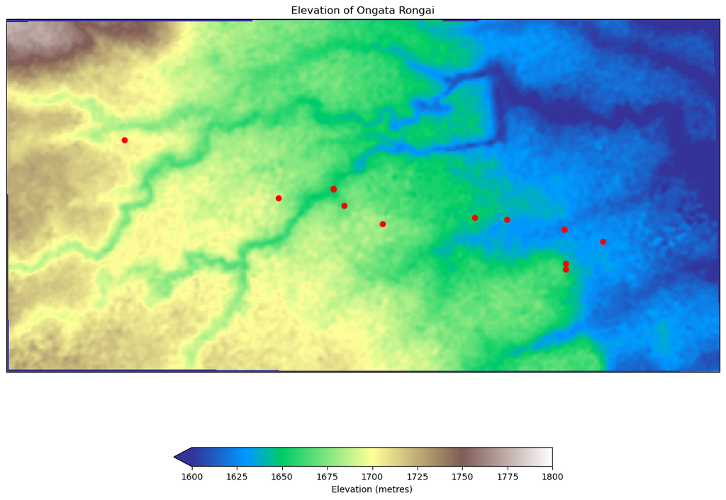

```python
# Plot the GPS points shapefile overlying the DEM

fig = plt.figure(figsize=[12, 8])
ax = fig.add_axes([0, 0, 1, 1], projection=ccrs.PlateCarree())
raster_image = topography.plot(ax=ax,
                              cmap='terrain',
                              vmax=1800,
                              vmin=1600,
                              label="Elevation Ongata Rongai",
                              cbar_kwargs={'orientation':  'horizontal',
                                          'shrink': 0.5,
                                          'label': 'Elevation (metres)'} )
plt.title("Elevation of Ongata Rongai")
shapefile.plot(ax=ax, color='red')
plt.show()
```

## Extracting elevation values from the DEM

Tired already? Of course yes. But luckily this is the last bit. We will create a `for` loop to access the altitudes at specific Lon-Lat coordinates on the DEM. We will first create a new column `elevation` and assign it the default value `0`. Any elevation values at our specific GPS points will be imputed to this default `0` value. Think of this logic as analogous to conducting a census using a Computerized Personal Assistant (CAPI), such as the tablets employed in the 2019 census. Every house within your jurisdiction has been assigned the value 0 in the tablet's census app. However, once you start conducting the census, the value of each household will be changed from the default 0 to the total number of people you counted residing in that household. So if you come across a house with 10 members, you will change the value of that house from 0 to 10, others to three, 12 and so on... It's the same we are doing to our shapefile... imputing altitude values to each Lon-Lat coordinate we come across in the table picked from their corresponding position in the DEM.

One more caveat. Our function could not load the `topography` raster we've just used above. But if we load the raster with our initial `rasterio.open()`, the for loop works magnificently. Do try to find out and see. Anyway, we work with what works so we christened our reprojected raster as `clipped_dem_rpj`.

```python
# Call the reprojected raster using rasterio package
clipped_dem_rpj = rasterio.open("E:/documents/gis800_articles/jupyter/terrain_dem/dem_files/clipped_dem_rpj.tif")
```

```python
# For loop to extract elevation values
shapefile['elevation'] = 0

for index, row in shapefile.iterrows():
    # Extracting attributes
    name = row['Descriptio']
    latitude = row['geometry'].y
    longitude = row['geometry'].x

    # DEM
    row, col = clipped_dem_rpj.index(longitude, latitude)
    dem_data = clipped_dem_rpj.read(1)

    print(f"Name: {name}, \tElevation (m): {dem_data[row, col]}")

    #
    shapefile['elevation'].loc[index] = dem_data[row, col]
```

```
Name: Junction at Magadi road, 	Elevation (m): 1703
Name: Start of murram road, 	Elevation (m): 1686
Name: Bend before reaching the bridge crossing river Kandisi, 	Elevation (m): 1646
Name: a few metres to the bridge, 	Elevation (m): 1647
Name: A group of zebras were sighted grazing in an open field, 	Elevation (m): 1663
Name: Twala centre, 	Elevation (m): 1675
Name: Overpass of SGR, 	Elevation (m): 1652
Name: Eucalyptus plantation next to SGR barrier, 	Elevation (m): 1638
Name: Location of seasonal river, 	Elevation (m): 1623
Name: A few metres past the bend adjacent to Cockpit hotel, 	Elevation (m): 1628
Name: Field after bend toward quarry, 	Elevation (m): 1648
Name: Quarry, 	Elevation (m): 1653
```

Works like magic. If this is all you wanted, you can end here. However, since being a good programmer means you avoid redundancy, we will create a function that mimics the above `for` loop.

```python
# Function to extract elevation values of a DEM using a shapefile (works for all .tifs and shapefiles

def createElevationColumn(shapefile: '.sh', dem:'.tif', column_name: 'str', geometry_column: 'str')->'gpd.GeoDataFrame':
    """This function is to create a new column called Elevation that consists of height values from the point positions on the dem
    Parameters:

    shapefile (.shp): A shapefile in the same projection as the reprojected raster
    dem (.tif): A Digital Elevation Model. This function works well with .tif format
    column_name ('str'): Write the column name in which you would like to associate your elevation values with eg. station names. Insert the column name in quotes (' ')
    geometry_column ('str'): The column name containing the Longitude_Latitude values (in that order). Must be a geometry column. Insert the name of this column in quotes (' ') like in column_name.

    Returns:
    gpd.GeoDataFrame: The result is a geoDataFrame with elevation values at Lon-Lat coordinates of each particular point (row) extracted from the DEM
    """
    shapefile['elevation'] = 0
    for index, row in shapefile.iterrows():
        name=row[column_name]
        longitude = row[geometry_column].x
        latitude = row[geometry_column].y

        row, col = dem.index(longitude, latitude)
        dem_data = dem.read(1)

        print(f"Name: {name}, \tElevation (m): {dem_data[row, col]}")


        shapefile['elevation'].loc[index] = dem_data[row, col]
```

Let's try out our genius function on two new variables of our shapefile and the reprojected clipped DEM.

```python
shapefile5 = gpd.read_file("E:/documents/gis800_articles/jupyter/terrain_dem/gps_files/gps_shapefile.shp")
```

```python
dem5 = rasterio.open("E:/documents/gis800_articles/jupyter/terrain_dem/dem_files/clipped_dem_rpj.tif")
```

```python
createElevationColumn(shapefile5, dem5, 'Point', 'geometry')
```

```
Name: 1, 	Elevation (m): 1703
Name: 2, 	Elevation (m): 1686
Name: 3, 	Elevation (m): 1646
Name: 4, 	Elevation (m): 1647
Name: 5, 	Elevation (m): 1663
Name: 6, 	Elevation (m): 1675
Name: 7, 	Elevation (m): 1652
Name: 8, 	Elevation (m): 1638
Name: 9, 	Elevation (m): 1623
Name: 10, 	Elevation (m): 1628
Name: 11, 	Elevation (m): 1648
Name: 12, 	Elevation (m): 1653
```

```python
shapefile5.head()
```

|  | Point | Latitude | Longitude | Accuracy(m | Descriptio | geometry | elevation |
| --- | --- | --- | --- | --- | --- | --- | --- |
| 0 | 1 | -1.390684 | 36.769671 | 4 | Junction at Magadi road | POINT (36.770 -1.391) | 1703 |
| 1 | 2 | -1.398675 | 36.790664 | 9 | Start of murram road | POINT (36.791 -1.399) | 1686 |
| 2 | 3 | -1.397448 | 36.798129 | 3 | Bend before reaching the bridge crossing river... | POINT (36.798 -1.397) | 1646 |
| 3 | 4 | -1.397348 | 36.798175 | 5 | a few metres to the bridge | POINT (36.798 -1.397) | 1647 |
| 4 | 5 | -1.399695 | 36.799621 | 3 | A group of zebras were sighted grazing in an o... | POINT (36.800 -1.400) | 1663 |

Hurrah! Our function works correctly! To make it look cooler, check in your contextual help that our docstrings is the reference guide for our `createElevationColumn` function.

# Conclusion

Digital Elevation Models (DEMs) have made our GIS work easier in that one doesn't have to go to the field to extract elevation values. In today's exercise, we saw how to plot a raster and a vector in one image, although it is far from sounding simple. We also used a for loop to extract the elevation values for each GPS point, and subsequently created a function for this task which can be replicated for any shapefile and raster.